# Introduction

## What is econometrics

**Econometrics** is “doing economics with data”

Or more formally, a set of statistical tools for analyzing economic relationships (and other relationships, econometrics isn’t just for economists)

In this class, we’re going to focus on one very useful set of tools, known broadly as **linear regression**

By the end of this course, you’ll know how to

- Estimate and analyze causal effects and other relationships using real-world data
- Test hypothesis about these relationships
- Predict economic and other variables
- Think about the difference between causal effects and statistical relationships

This introductory lecture will give you a feel for what you can do with econometrics

But first, a bit more about the class

## Class info

**Syllabus:** It is your responsibility to read the *entire* syllabus to familiarize yourself with important policies and dates for the class

**Textbook:** Our main source will be my slides, so there is no required text. However, the “official” text for the course is *Introductory Econometrics: Intuition, Proof and Practice* by Zax. I have also listed some additional references in the syllabus for those who want to learn about topics beyond what we’ll cover

**Software:** A lot of the work we do in this class will be on computers. We will use two different programs: [gretl](https://gretl.sourceforge.net/) and [R](https://www.r-project.org/). Both programs are free and run on any OS

Gretl is easier to use, but R has more powerful programming capabilities. You can use whichever you like better, though students interested in doing more advanced research should consider learning a little R. If you decide to use R, you might want to download [R Studio](https://posit.co/downloads), a free program which facilitates R programming

I will show you a little bit about how to use both programs in class. If you are interested in learning more, I have listed some additional resources in the syllabus

*Let me know as soon as possible if you have any difficulties installing these programs.*

## An example

Let’s use an example to motivate what econometrics is all about, and why you want to learn it

Along the way, we’ll also learn the basics of how our software works

The question we’ll ask is an important, and long-standing, one in labor economics:

> Does having more education increase one’s wages?

Why is this an important question?

Isn’t it obvious that education and wages are related?

In economics, there are two main theories of education:

1. The human capital investment model: education increases your skills, making you more productive and increasing your wages
2. The Spence signalling model: education does not affect producivity, instead people “jump through the hoops” of getting an education to prove to employers that they are talented

The first theory says that education should affect wages, while the second says that it should not

Let’s investigate this using some data on hourly wages (measured in cents), education, and a bunch of other variables

We’ll load these data, along with some useful “package” that extend R’s capabilities

```r
library(tidyverse)
card <- read_csv("card.csv")
```

Next, let’s look at some summary statistics (this is always an important step)

```r
summary(card)
```

```
       id           nearc2           nearc4            educ
 Min.   :   2   Min.   :0.0000   Min.   :0.0000   Min.   : 1.00
 1st Qu.:1276   1st Qu.:0.0000   1st Qu.:0.0000   1st Qu.:12.00
 Median :2541   Median :0.0000   Median :1.0000   Median :13.00
 Mean   :2582   Mean   :0.4409   Mean   :0.6821   Mean   :13.26
 3rd Qu.:3859   3rd Qu.:1.0000   3rd Qu.:1.0000   3rd Qu.:16.00
 Max.   :5225   Max.   :1.0000   Max.   :1.0000   Max.   :18.00

      age           fatheduc      motheduc         weight
 Min.   :24.00   Min.   : 0    Min.   : 0.00   Min.   :  75607
 1st Qu.:25.00   1st Qu.: 8    1st Qu.: 8.00   1st Qu.: 122798
 Median :28.00   Median :10    Median :12.00   Median : 365200
 Mean   :28.12   Mean   :10    Mean   :10.35   Mean   : 321185
 3rd Qu.:31.00   3rd Qu.:12    3rd Qu.:12.00   3rd Qu.: 406024
 Max.   :34.00   Max.   :18    Max.   :18.00   Max.   :1752340
                 NA's   :690   NA's   :353
    momdad14         sinmom14          step14            reg661
 Min.   :0.0000   Min.   :0.0000   Min.   :0.00000   Min.   :0.00000
 1st Qu.:1.0000   1st Qu.:0.0000   1st Qu.:0.00000   1st Qu.:0.00000
 Median :1.0000   Median :0.0000   Median :0.00000   Median :0.00000
 Mean   :0.7894   Mean   :0.1007   Mean   :0.03887   Mean   :0.04651
 3rd Qu.:1.0000   3rd Qu.:0.0000   3rd Qu.:0.00000   3rd Qu.:0.00000
 Max.   :1.0000   Max.   :1.0000   Max.   :1.00000   Max.   :1.00000

     reg662           reg663           reg664            reg665
 Min.   :0.0000   Min.   :0.0000   Min.   :0.00000   Min.   :0.0000
 1st Qu.:0.0000   1st Qu.:0.0000   1st Qu.:0.00000   1st Qu.:0.0000
 Median :0.0000   Median :0.0000   Median :0.00000   Median :0.0000
 Mean   :0.1608   Mean   :0.1957   Mean   :0.06412   Mean   :0.2083
 3rd Qu.:0.0000   3rd Qu.:0.0000   3rd Qu.:0.00000   3rd Qu.:0.0000
 Max.   :1.0000   Max.   :1.0000   Max.   :1.00000   Max.   :1.0000

     reg666            reg667         reg668            reg669
 Min.   :0.00000   Min.   :0.00   Min.   :0.00000   Min.   :0.00000
 1st Qu.:0.00000   1st Qu.:0.00   1st Qu.:0.00000   1st Qu.:0.00000
 Median :0.00000   Median :0.00   Median :0.00000   Median :0.00000
 Mean   :0.09601   Mean   :0.11   Mean   :0.02824   Mean   :0.09037
 3rd Qu.:0.00000   3rd Qu.:0.00   3rd Qu.:0.00000   3rd Qu.:0.00000
 Max.   :1.00000   Max.   :1.00   Max.   :1.00000   Max.   :1.00000

```

[output cut: 16 more lines]

```
       IQ           married         libcrd14          exper
 Min.   : 50.0   Min.   :1.000   Min.   :0.0000   Min.   : 0.000
 1st Qu.: 93.0   1st Qu.:1.000   1st Qu.:0.0000   1st Qu.: 6.000
 Median :103.0   Median :1.000   Median :1.0000   Median : 8.000
 Mean   :102.4   Mean   :2.271   Mean   :0.6743   Mean   : 8.856
 3rd Qu.:113.0   3rd Qu.:4.000   3rd Qu.:1.0000   3rd Qu.:11.000
 Max.   :149.0   Max.   :6.000   Max.   :1.0000   Max.   :23.000
 NA's   :949     NA's   :7       NA's   :13
     lwage          expersq
 Min.   :4.605   Min.   :  0.00
 1st Qu.:5.977   1st Qu.: 36.00
 Median :6.287   Median : 64.00
 Mean   :6.262   Mean   : 95.58
 3rd Qu.:6.564   3rd Qu.:121.00
 Max.   :7.785   Max.   :529.00
```

To get a preliminary sense of how education and wages are related, let’s plot them. We can do this using the `ggplot` command, which makes nice plots (but takes some learning):

```r
ggplot(data=card, aes(x=educ, y=wage)) + geom_point()
```

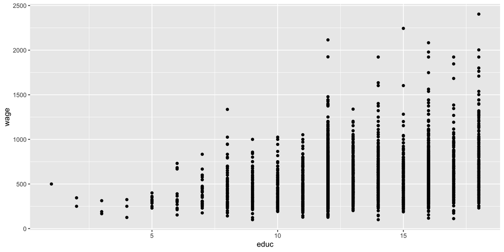

It does appear that those with more education earn higher wages, but let’s formalize this relationship

Specifically, let’s use a linear model:

$$wage = \alpha + \beta educ + \varepsilon$$
Here, $wage$ is the **dependent variable** and $educ$ is the called an **independent variable**, **explanatory variable** or **regressor**

$\alpha$ is the intercept and $\beta$ is the slope coefficient

$\varepsilon$ is called the **error term,** and it reflects the fact that wages depend on other things besides education

**Regression** is a way of using data to *estimate* the parameters $\alpha$ and $\beta$ in our model

Our estimated regression will take the form:

$$\widehat{wage} = a + b \cdot educ$$

The “hat” on wage means that this equation is a **prediction** of the wage for someone with a particular amount of education

$$\widehat{wage} = a + b \cdot educ$$

$a$ is our estimate of the true intercept $\alpha$ (we’ll say more about what “true” means later)

We can interpret $a$ as the wage that we’d predict for someone with no education

$b$ is our estimate of the true slope coefficient $\beta$

We can interpret $b$ as how an extra year of eduation will increase the predicted wage:

$$b = \frac{\Delta \widehat{wage}}{\Delta educ}$$

We can easily estimate the regression using the `lm` (linear model) command:

```r
educ.mod.1 <- lm(wage ~ educ, data=card)
summary(educ.mod.1)
```

```
Call:
lm(formula = wage ~ educ, data = card)

Residuals:
    Min      1Q  Median      3Q     Max
-576.09 -173.36  -34.12  127.82 1686.25

Coefficients:
            Estimate Std. Error t value Pr(>|t|)
(Intercept)  183.949     23.104   7.962 2.38e-15 ***
educ          29.655      1.708  17.368  < 2e-16 ***
---
Signif. codes:  0 '***' 0.001 '**' 0.01 '*' 0.05 '.' 0.1 ' ' 1

Residual standard error: 250.7 on 3008 degrees of freedom
Multiple R-squared:  0.09114,   Adjusted R-squared:  0.09084
F-statistic: 301.6 on 1 and 3008 DF,  p-value: < 2.2e-16
```

According to our model,

$$\widehat{wage} = 183.95 + 29.66 \cdot educ$$

The value of $b=29.66$ means that every additional year of education increases the predicted wage by about $.30

This suggests that wages and education are *related*, but that’s not the question

The human capital model says that education has a **causal effect** on the wage

The signalling model says that there is only a “statistical association” because talented people get more education to signal their abilities

One problem is that people with more education have, by definition, spent less time in the workforce

This means that they have less experience, which probably also affects wages

On one hand, education might *increase* wages. On the other hand, more educated people have less experience, which might *decrease* wages

The overall relationship that we see in the data between education in wages reflects a combination of both of these factors

This might cause our regression to *understate* the effect of education on wages

We can address this by *controlling* for experience, or *holding experience constant*

In other words, looking at how wages differ between people with different amounts of education, but the *same* experience

This is an example of the idea of *ceteris parabus*, which means “all else constant”

Now, our regression becomes

$$\widehat{wage} = a + b_1 \cdot educ + b_2 \cdot exper$$

$$b_1 = \frac{\Delta \widehat{wage}}{\Delta educ} \Bigg|_{exper}$$

This is called a **multivariate** regression, and we’ll see the details of how it works later

For now, let’s see how it affects our estimates

```r
educ.mod.2 <- lm(wage ~ educ + exper, data=card)
summary(educ.mod.2)
```

```
Call:
lm(formula = wage ~ educ + exper, data = card)

Residuals:
    Min      1Q  Median      3Q     Max
-647.16 -161.20  -29.57  124.79 1612.62

Coefficients:
            Estimate Std. Error t value Pr(>|t|)
(Intercept) -375.588     37.802  -9.936   <2e-16 ***
educ          55.055      2.140  25.722   <2e-16 ***
exper         25.142      1.383  18.174   <2e-16 ***
---
Signif. codes:  0 '***' 0.001 '**' 0.01 '*' 0.05 '.' 0.1 ' ' 1

Residual standard error: 238 on 3007 degrees of freedom
Multiple R-squared:  0.1811,    Adjusted R-squared:  0.1805
F-statistic: 332.5 on 2 and 3007 DF,  p-value: < 2.2e-16
```

Controlling for experience *increases* the slope coefficient on education

Since more educated people have less experience (and experience probably increases wages), this is exactly what we expect

When we control for experience by holding it constant, the apparent relationship betwen education and wages increases

Under the signalling theory, we might think that people with more education have higher abilities

To account for this, we want to try to *control* for ability—i.e., see how wages differ between people with different education but the *same* underlying ability

Of course, “ability” is an ambiguous concept, but our data contains variables that might be considered measures of ability

For starters, we can control for individual’s IQ test scores, as well as their scores on a test that measures “knowledge of the world of work”:

```r
educ.mod.3 <- lm(wage ~ educ + exper + IQ + KWW, data=card)
summary(educ.mod.3)
```

```
Call:
lm(formula = wage ~ educ + exper + IQ + KWW, data = card)

Residuals:
    Min      1Q  Median      3Q     Max
-618.80 -151.35  -30.79  120.55 1619.31

Coefficients:
             Estimate Std. Error t value Pr(>|t|)
(Intercept) -445.4814    58.0504  -7.674 2.57e-14 ***
educ          38.4039     3.4914  11.000  < 2e-16 ***
exper         23.3413     1.9970  11.688  < 2e-16 ***
IQ             1.2912     0.4287   3.012  0.00263 **
KWW            5.4820     0.8971   6.111 1.19e-09 ***
---
Signif. codes:  0 '***' 0.001 '**' 0.01 '*' 0.05 '.' 0.1 ' ' 1

Residual standard error: 238.5 on 2035 degrees of freedom
  (970 observations deleted due to missingness)
Multiple R-squared:  0.1846,    Adjusted R-squared:  0.183
F-statistic: 115.2 on 4 and 2035 DF,  p-value: < 2.2e-16
```

Now the coefficient on education *decreases* from 55 to 38

Again, this is exactly what we expect

People with higher ability (as measured by IQ and KWW) probably have more education, but would earn higher wages regardless of their education

When we hold IQ and KWW constant, the apparent relationship between education and wages shrinks

We might also be concerned that people inherit some of their abilities from their parents

To try to address this, let’s control for parental education and whether individuals grew up in a household where someone had a library card

```r
educ.mod.4 <- lm(wage ~ educ + exper + IQ + KWW + motheduc + fatheduc + libcrd14, data=card)
summary(educ.mod.4)
```

```
Call:
lm(formula = wage ~ educ + exper + IQ + KWW + motheduc + fatheduc +
    libcrd14, data = card)

Residuals:
    Min      1Q  Median      3Q     Max
-644.00 -151.36  -30.76  120.65 1588.56

Coefficients:
             Estimate Std. Error t value Pr(>|t|)
(Intercept) -485.8863    68.0075  -7.145 1.37e-12 ***
educ          39.7635     4.0080   9.921  < 2e-16 ***
exper         28.0601     2.3735  11.822  < 2e-16 ***
IQ             1.1266     0.5002   2.252  0.02444 *
KWW            3.4802     1.0579   3.290  0.00102 **
motheduc       2.9579     2.6684   1.109  0.26781
fatheduc       2.4969     2.2970   1.087  0.27719
libcrd14      21.3645    15.4140   1.386  0.16593
---
Signif. codes:  0 '***' 0.001 '**' 0.01 '*' 0.05 '.' 0.1 ' ' 1

Residual standard error: 241.6 on 1593 degrees of freedom
  (1409 observations deleted due to missingness)
Multiple R-squared:  0.1797,    Adjusted R-squared:  0.1761
F-statistic: 49.85 on 7 and 1593 DF,  p-value: < 2.2e-16
```

The key point is that, even after controlling for all of these factors, the relationship between education and wages is still positive (this result is also “statistically strong” in a sense that we’ll clarify later)

This suggests that the relationship between education and wages that we have estimated might be **causal** and not just a “statistical association”

We can interpret this as evidence in favor of the human capital theory over the signalling theory (most studies of this phenomenon reach similar conclusions)

Of course, it’s always possible that there are other factors that we should be controlling for, but aren’t

Later, we’ll discuss other techniques that we can use to try to be sure that the relationships that we’re estimating are actually causal (although the truth is that you can never be sure)